# Correlation of HNRNPH and PSI levels in BRCA tumor samples

Mario Keller

Faculty of Biological Sciences, Goethe University Frankfurt

12 December 2022

```r
knitr::opts_chunk$set(echo = TRUE, message=FALSE, warning=FALSE,
                      crop=NULL, results = TRUE)
```

```r
library(tidyverse)
library(DESeq2)
library(knitr)
library(ggbeeswarm)
library(kableExtra)
```

```r
myTheme <- theme_bw() +
    theme(axis.text = element_text(size = 14, colour="black"),
          axis.title = element_text(size=16, colour="black"),
          axis.ticks=element_line(color="black"),
          axis.ticks.length=unit(.15, "cm"),
          panel.border=element_rect(color="black", fill = NA),
          panel.background = element_blank(),
          plot.background = element_blank(),
          legend.text = element_text(size=12),
          legend.position = "none")
```

```r
projectDir <- "/Users/mariokeller/projects/HNRNPH_project/Tretow_et_al_2023"

tcgaDir <- paste0(projectDir, "/8_TCGA_analysis")
```

# 1 Background

The data so far led to the identification of CE and ALE events showing cooperatively enhanced and repressed HNRNPH regulation. As the RNA-seq experiments were performed in the human breast cancer cell line MCF7, we raised the question whether these events show a similar dependence on HNRNPH levels and direction of regulation in the TCGA BRCA cohort. To test this, expression of *HNRNPH1* and *HNRNPH2* and PSI levels of the enhanced and repressed CE and ALE events were computed for each BRCA tumor sample. In addition, the non-regulated CE events were also checked to see if these are also not affected in the BRCA samples.

# 2 Data

Vst-transformed and batch corrected expression values are loaded from a RDS-File created with *Calculate_expression_BRCA.R*.

Sample meta information is loaded from a RDS-File created with *Calculate_expression_BRCA.R*.

PSI values of junctions of interest are loaded from a RDS-File created with *Calculate_PSIs_BRCA.R*.

```r
vsdBatchCorrected<- readRDS(paste0(tcgaDir,"/rds_files/BRCA_vsdBatchCorrected.rds"))

metaInformation <- readRDS(paste0(tcgaDir,"/rds_files/BRCA_metaInformation.rds"))

PSIs <- readRDS(paste0(tcgaDir,"/rds_files/BRCA_PSI.rds"))
```

A data.frame with the expression levels of *HNRNPH1* (ENSG00000169045.17) and *HNRNPH2* (ENSG00000126945.8) is created.

```r
# Each row is a sample and columns are the samplebarcode and HNRNPH1 and HNRNPH2
#   expression levels
HNRNPHexpression <- data.frame(geneName=c("HNRNPH1", "HNRNPH2"),
                               vsdBatchCorrected[match(c("ENSG00000169045.17",
                                                         "ENSG00000126945.8"),
                                                       rownames(vsdBatchCorrected)),] %>%
                                   assay) %>%
    pivot_longer(., cols=-1, names_to="tcgaSampleBarcode", values_to="vst") %>%
    mutate(tcgaSampleBarcode=gsub(".", "-", tcgaSampleBarcode, fixed = T)) %>%
    pivot_wider(., names_from = geneName, values_from=vst)

# The participant barcode and the sample type are added
HNRNPHexpression <- HNRNPHexpression %>%
    left_join(., metaInformation %>% dplyr::select(tcga.tcga_barcode,
                                                   tcga.gdc_cases.submitter_id,
                                                   tcga.gdc_cases.samples.sample_type),
              by=c("tcgaSampleBarcode" = "tcga.tcga_barcode")) %>%
    dplyr::rename(tcgaPatientBarcode = tcga.gdc_cases.submitter_id,
           sampleType = tcga.gdc_cases.samples.sample_type)
```

Splicing events are reduced to those of the category “Coop-Enh”, “Coop-Rep” and “nonReg”. Note that Coop-Enh and Coop-Rep comprise CE and ALE events.

```r
# Remove the quantifications od the HNRNPH1 NMD Isoform and
#   use for the non-regulated CE events "nonReg" as Hill category
PSIs <- PSIs %>%
    dplyr::filter(eventType != "HNRNPH1nmdIsoform") %>%
    dplyr::mutate(hillCat = ifelse(is.na(hillCat), "nonReg", hillCat))

# Filter for the three Hill categories of interest
PSIs <- PSIs %>% dplyr::filter(hillCat %in% c("Coop-Enh", "Coop-Rep", "nonReg"))
```

# 3 Correlations between *HNRNPH1/2* and Coop-Enh, Coop-Rep or nonReg events

The PSI values cooperatively enhanced and repressed CE and ALE events as well as the non-regulated CE events are correlated with the expression of *HNRNPH1* and *HNRNPH2*.

Correlations were performed for an event if at least 10 tumor samples had a PSI value for the event. Correlations were considered significant if their adjusted P value (BH correction) was $\le$ 0.05. Boxplots are are based on significant and non-signififcant correlations. Significance is shown by the transparency (alpha) of the points.

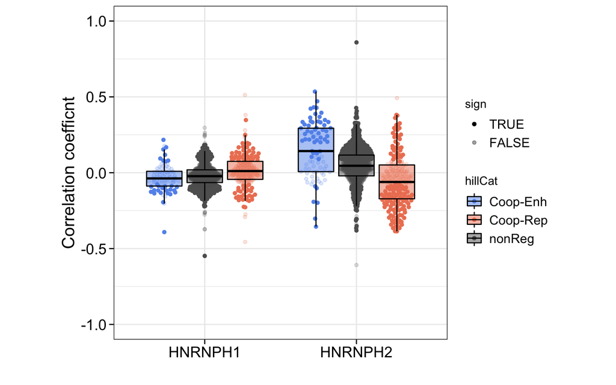

```r
corRes <- lapply(PSIs$eventID %>% unique, function(tmpEventID){

    # Combine HNRNPH expression levels and PSI values in a single data.frame
    df <- inner_join(HNRNPHexpression,
                         PSIs %>%
                             dplyr::filter(eventID == tmpEventID) %>%
                             dplyr::select(tcgaPatientBarcode, tcgaSampleBarcode, sampleType, PSI),
                     by = c("tcgaSampleBarcode", "tcgaPatientBarcode", "sampleType")) %>%
        dplyr::filter(sampleType=="Primary Tumor")

    # If there are less than 10 samples return an empty data.frame
    if(nrow(df) < 10){
        return(data.frame())
    }

    # Create the output data.frame
    df <- data.frame(gene=c("HNRNPH1", "HNRNPH2"),
                     eventID=tmpEventID,
                     hillCat= PSIs %>% dplyr::filter(eventID == tmpEventID) %>%
                         pull(hillCat) %>% unique,
                     r=c(cor.test(df$HNRNPH1,
                                  df$PSI)$estimate,
                         cor.test(df$HNRNPH2,
                                  df$PSI)$estimate),
                     pval=c(cor.test(df$HNRNPH1,
                                     df$PSI)$p.value,
                            cor.test(df$HNRNPH2,
                                     df$PSI)$p.value))
    return(df)
}) %>% bind_rows()

# Do the FDR corecction
corRes <- corRes %>% mutate(pvalAdj = p.adjust(pval, method = "BH")) %>%
    mutate(sign=ifelse(pvalAdj <= 0.05, TRUE, FALSE))

corRes$hillCat <- factor(corRes$hillCat, levels=c("Coop-Enh","nonReg", "Coop-Rep"))

ggplot(mapping=aes(x=gene, y=r, col=hillCat, fill=hillCat, alpha=sign)) +
        geom_quasirandom(data=corRes %>% dplyr::filter(sign), dodge.width = .8, size=1.25) +
        geom_quasirandom(data=corRes %>% dplyr::filter(!sign), dodge.width = .8, size=1.25) +
        geom_boxplot(data=corRes, alpha=.5, outlier.size = -1, col="black",
                     position = position_dodge(width = .8), width = .7) +
        scale_fill_manual(values=c("Coop-Enh"="cornflowerblue", "Coop-Rep"="salmon2", "nonReg"="#606060")) +
        scale_color_manual(values=c("Coop-Enh"="cornflowerblue", "Coop-Rep"="salmon2", "nonReg"="#606060")) +
        scale_alpha_manual(values=c("TRUE" = 1, "FALSE" = .2)) +
        coord_cartesian(ylim=c(-1, 1)) +
        scale_y_continuous(breaks=seq(-1, 1, by=0.5)) +
        labs(x="", y="Correlation coefficnt") +
        myTheme + theme(legend.position = "right", aspect.ratio=1)
```

At least for *HNRNPH2* we can see the expected regulation, namely that enhanced CE and ALE events are positively correlated with *HNRNPH2* levels and repressed CE and ALE events negatively. The non-regulated events have a median correlation coefficient of around 0.